# Risk Factor Analysis

## Outcome Variable

**Outcome Variable:** whz

## Predictor Variables

**Intervention Variable:** mwtkg

**Adjustment Set:**

- arm
- W_mage
- meducyrs
- feducyrs
- single
- brthmon
- W_parity
- delta_W_mage
- delta_meducyrs
- delta_feducyrs
- delta_single
- delta_brthmon
- delta_W_parity

## Stratifying Variables

The analysis was stratified on these variable(s):

- agecat
- studyid
- country

## Data Summary

| agecat | studyid | country | mwtkg | n_cell | n | outcome_variable |
| --- | --- | --- | --- | --- | --- | --- |
| Birth | JiVitA-3 | BANGLADESH | >=58 kg | 427 | 17995 | whz |
| Birth | JiVitA-3 | BANGLADESH | <52 kg | 16351 | 17995 | whz |
| Birth | JiVitA-3 | BANGLADESH | [52-58) kg | 1217 | 17995 | whz |
| Birth | MAL-ED | BANGLADESH | >=58 kg | 37 | 209 | whz |
| Birth | MAL-ED | BANGLADESH | <52 kg | 131 | 209 | whz |
| Birth | MAL-ED | BANGLADESH | [52-58) kg | 41 | 209 | whz |
| Birth | MAL-ED | BRAZIL | >=58 kg | 33 | 61 | whz |
| Birth | MAL-ED | BRAZIL | <52 kg | 14 | 61 | whz |
| Birth | MAL-ED | BRAZIL | [52-58) kg | 14 | 61 | whz |
| Birth | MAL-ED | INDIA | >=58 kg | 6 | 41 | whz |
| Birth | MAL-ED | INDIA | <52 kg | 28 | 41 | whz |
| Birth | MAL-ED | INDIA | [52-58) kg | 7 | 41 | whz |
| Birth | MAL-ED | NEPAL | >=58 kg | 9 | 26 | whz |
| Birth | MAL-ED | NEPAL | <52 kg | 7 | 26 | whz |
| Birth | MAL-ED | NEPAL | [52-58) kg | 10 | 26 | whz |
| Birth | MAL-ED | PERU | >=58 kg | 82 | 221 | whz |
| Birth | MAL-ED | PERU | <52 kg | 81 | 221 | whz |
| Birth | MAL-ED | PERU | [52-58) kg | 58 | 221 | whz |
| Birth | MAL-ED | SOUTH AFRICA | >=58 kg | 69 | 100 | whz |
| Birth | MAL-ED | SOUTH AFRICA | <52 kg | 10 | 100 | whz |
| Birth | MAL-ED | SOUTH AFRICA | [52-58) kg | 21 | 100 | whz |
| Birth | MAL-ED | TANZANIA, UNITED REPUBLIC OF | >=58 kg | 44 | 113 | whz |
| Birth | MAL-ED | TANZANIA, UNITED REPUBLIC OF | <52 kg | 40 | 113 | whz |
| Birth | MAL-ED | TANZANIA, UNITED REPUBLIC OF | [52-58) kg | 29 | 113 | whz |
| Birth | NIH-Birth | BANGLADESH | >=58 kg | 79 | 575 | whz |
| Birth | NIH-Birth | BANGLADESH | <52 kg | 414 | 575 | whz |
| Birth | NIH-Birth | BANGLADESH | [52-58) kg | 82 | 575 | whz |
| Birth | NIH-Crypto | BANGLADESH | >=58 kg | 183 | 704 | whz |
| Birth | NIH-Crypto | BANGLADESH | <52 kg | 381 | 704 | whz |
| Birth | NIH-Crypto | BANGLADESH | [52-58) kg | 140 | 704 | whz |

[output cut: 105 more lines]

The following strata were considered:

- agecat: 24 months, studyid: JiVitA-3, country: BANGLADESH
- agecat: 24 months, studyid: LCNI-5, country: MALAWI
- agecat: 24 months, studyid: MAL-ED, country: BANGLADESH
- agecat: 24 months, studyid: MAL-ED, country: BRAZIL
- agecat: 24 months, studyid: MAL-ED, country: INDIA
- agecat: 24 months, studyid: MAL-ED, country: NEPAL
- agecat: 24 months, studyid: MAL-ED, country: PERU
- agecat: 24 months, studyid: MAL-ED, country: SOUTH AFRICA
- agecat: 24 months, studyid: MAL-ED, country: TANZANIA, UNITED REPUBLIC OF
- agecat: 24 months, studyid: NIH-Birth, country: BANGLADESH
- agecat: 24 months, studyid: NIH-Crypto, country: BANGLADESH
- agecat: 24 months, studyid: PROBIT, country: BELARUS
- agecat: 24 months, studyid: PROVIDE, country: BANGLADESH
- agecat: 24 months, studyid: TanzaniaChild2, country: TANZANIA, UNITED REPUBLIC OF
- agecat: 24 months, studyid: ZVITAMBO, country: ZIMBABWE
- agecat: 6 months, studyid: JiVitA-3, country: BANGLADESH
- agecat: 6 months, studyid: LCNI-5, country: MALAWI
- agecat: 6 months, studyid: MAL-ED, country: BANGLADESH
- agecat: 6 months, studyid: MAL-ED, country: BRAZIL
- agecat: 6 months, studyid: MAL-ED, country: INDIA
- agecat: 6 months, studyid: MAL-ED, country: NEPAL
- agecat: 6 months, studyid: MAL-ED, country: PERU
- agecat: 6 months, studyid: MAL-ED, country: SOUTH AFRICA
- agecat: 6 months, studyid: MAL-ED, country: TANZANIA, UNITED REPUBLIC OF
- agecat: 6 months, studyid: NIH-Birth, country: BANGLADESH
- agecat: 6 months, studyid: NIH-Crypto, country: BANGLADESH
- agecat: 6 months, studyid: PROBIT, country: BELARUS
- agecat: 6 months, studyid: PROVIDE, country: BANGLADESH
- agecat: 6 months, studyid: SAS-CompFeed, country: INDIA
- agecat: 6 months, studyid: TanzaniaChild2, country: TANZANIA, UNITED REPUBLIC OF
- agecat: 6 months, studyid: ZVITAMBO, country: ZIMBABWE
- agecat: Birth, studyid: JiVitA-3, country: BANGLADESH
- agecat: Birth, studyid: MAL-ED, country: BANGLADESH
- agecat: Birth, studyid: MAL-ED, country: BRAZIL
- agecat: Birth, studyid: MAL-ED, country: INDIA
- agecat: Birth, studyid: MAL-ED, country: NEPAL
- agecat: Birth, studyid: MAL-ED, country: PERU
- agecat: Birth, studyid: MAL-ED, country: SOUTH AFRICA
- agecat: Birth, studyid: MAL-ED, country: TANZANIA, UNITED REPUBLIC OF
- agecat: Birth, studyid: NIH-Birth, country: BANGLADESH
- agecat: Birth, studyid: NIH-Crypto, country: BANGLADESH
- agecat: Birth, studyid: PROBIT, country: BELARUS
- agecat: Birth, studyid: PROVIDE, country: BANGLADESH
- agecat: Birth, studyid: SAS-CompFeed, country: INDIA
- agecat: Birth, studyid: ZVITAMBO, country: ZIMBABWE

### Dropped Strata

Some strata were dropped due to rare outcomes:

- agecat: 24 months, studyid: TanzaniaChild2, country: TANZANIA, UNITED REPUBLIC OF

## Methods Detail

We’re interested in the causal parameters $E[Y_a]$ for all values of $a \in \mathcal{A}$. These parameters represent the mean outcome if, possibly contrary to fact, we intervened to set all units to have $A=a$. Under the randomization and positivity assumptions, these are identified by the statistical parameters $\psi_a=E_W[E_{Y|A,W}(Y|A=a,W)]$. In addition, we’re interested in the mean of $Y$, $E[Y]$ under no intervention (the observed mean). We will estimate these parameters by using SuperLearner to fit the relevant likelihood factors – $E_{Y|A,W}(Y|A=a,W)$ and $p(A=a|W)$, and then updating our likelihood fit using a joint TMLE.

For unadjusted analyses ($W=\{\}$), initial likelihoods were estimated using Lrnr_glm to estimate the simple $E(Y|A)$ and Lrnr_mean to estimate $p(A)$. For adjusted analyses, a small library containing Lrnr_glmnet, Lrnr_xgboost, and Lrnr_mean was used.

Having estimated these parameters, we will then use the delta method to estimate relative risks and attributable risks relative to a prespecified baseline level of $A$.

# Results Detail

## Results Plots

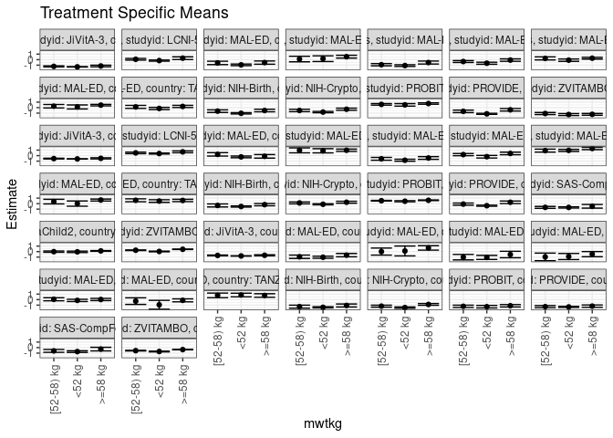

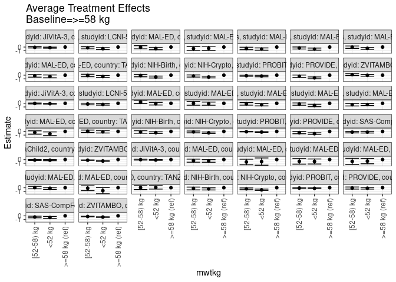

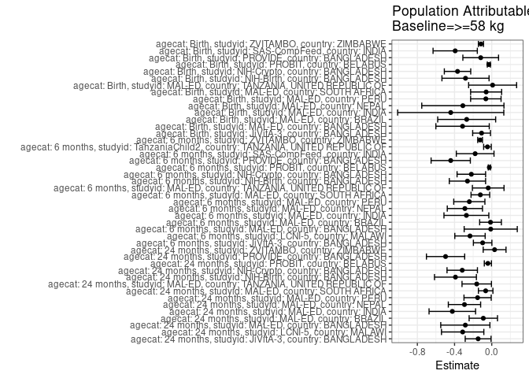

## Results Table

### Parameter: TSM

| agecat | studyid | country | intervention_level | baseline_level | estimate | ci_lower | ci_upper |
| --- | --- | --- | --- | --- | --- | --- | --- |
| Birth | JiVitA-3 | BANGLADESH | >=58 kg | NA | -0.6685337 | -0.7666617 | -0.5704057 |
| Birth | JiVitA-3 | BANGLADESH | <52 kg | NA | -0.7878411 | -0.8073129 | -0.7683694 |
| Birth | JiVitA-3 | BANGLADESH | [52-58) kg | NA | -0.6929993 | -0.7609383 | -0.6250603 |
| Birth | MAL-ED | BANGLADESH | >=58 kg | NA | -0.6394752 | -0.9388487 | -0.3401018 |
| Birth | MAL-ED | BANGLADESH | <52 kg | NA | -1.0227773 | -1.2084161 | -0.8371385 |
| Birth | MAL-ED | BANGLADESH | [52-58) kg | NA | -0.9378535 | -1.2384438 | -0.6372631 |
| Birth | MAL-ED | BRAZIL | >=58 kg | NA | 0.6714168 | 0.2711035 | 1.0717302 |
| Birth | MAL-ED | BRAZIL | <52 kg | NA | 0.1196489 | -0.7776153 | 1.0169131 |
| Birth | MAL-ED | BRAZIL | [52-58) kg | NA | 0.0066004 | -0.6339376 | 0.6471384 |
| Birth | MAL-ED | INDIA | >=58 kg | NA | -0.5266667 | -1.1151354 | 0.0618020 |
| Birth | MAL-ED | INDIA | <52 kg | NA | -1.0517857 | -1.4197431 | -0.6838283 |
| Birth | MAL-ED | INDIA | [52-58) kg | NA | -1.0100000 | -1.5034877 | -0.5165123 |
| Birth | MAL-ED | NEPAL | >=58 kg | NA | -0.4577778 | -0.9265727 | 0.0110172 |
| Birth | MAL-ED | NEPAL | <52 kg | NA | -0.8900000 | -1.4411585 | -0.3388415 |
| Birth | MAL-ED | NEPAL | [52-58) kg | NA | -0.9630000 | -1.6574487 | -0.2685513 |
| Birth | MAL-ED | PERU | >=58 kg | NA | 0.0205698 | -0.1768429 | 0.2179825 |
| Birth | MAL-ED | PERU | <52 kg | NA | -0.1433138 | -0.3461706 | 0.0595431 |
| Birth | MAL-ED | PERU | [52-58) kg | NA | 0.0578849 | -0.2186090 | 0.3343789 |
| Birth | MAL-ED | SOUTH AFRICA | >=58 kg | NA | -0.1325801 | -0.4033854 | 0.1382252 |
| Birth | MAL-ED | SOUTH AFRICA | <52 kg | NA | -0.9439124 | -1.7509511 | -0.1368737 |
| Birth | MAL-ED | SOUTH AFRICA | [52-58) kg | NA | -0.2754509 | -0.8753072 | 0.3244054 |
| Birth | MAL-ED | TANZANIA, UNITED REPUBLIC OF | >=58 kg | NA | 0.7490288 | 0.4249633 | 1.0730943 |
| Birth | MAL-ED | TANZANIA, UNITED REPUBLIC OF | <52 kg | NA | 0.8360259 | 0.5029115 | 1.1691403 |
| Birth | MAL-ED | TANZANIA, UNITED REPUBLIC OF | [52-58) kg | NA | 0.7703223 | 0.3497819 | 1.1908627 |
| Birth | NIH-Birth | BANGLADESH | >=58 kg | NA | -1.0676967 | -1.3390685 | -0.7963249 |
| Birth | NIH-Birth | BANGLADESH | <52 kg | NA | -1.4026180 | -1.5116431 | -1.2935928 |
| Birth | NIH-Birth | BANGLADESH | [52-58) kg | NA | -1.2856774 | -1.5578894 | -1.0134654 |
| Birth | NIH-Crypto | BANGLADESH | >=58 kg | NA | -0.8755070 | -1.0364363 | -0.7145776 |
| Birth | NIH-Crypto | BANGLADESH | <52 kg | NA | -1.4556322 | -1.5720912 | -1.3391732 |
| Birth | NIH-Crypto | BANGLADESH | [52-58) kg | NA | -1.1910063 | -1.3716410 | -1.0103716 |

[output cut: 102 more lines]

### Parameter: E(Y)

| agecat | studyid | country | intervention_level | baseline_level | estimate | ci_lower | ci_upper |
| --- | --- | --- | --- | --- | --- | --- | --- |
| Birth | JiVitA-3 | BANGLADESH | NA | NA | -0.7780622 | -0.7970926 | -0.7590319 |
| Birth | MAL-ED | BANGLADESH | NA | NA | -0.9533493 | -1.0984355 | -0.8082631 |
| Birth | MAL-ED | BRAZIL | NA | NA | 0.4018033 | 0.0834093 | 0.7201973 |
| Birth | MAL-ED | INDIA | NA | NA | -0.9678049 | -1.2522118 | -0.6833979 |
| Birth | MAL-ED | NEPAL | NA | NA | -0.7684615 | -1.1257770 | -0.4111460 |
| Birth | MAL-ED | PERU | NA | NA | -0.0429864 | -0.1658406 | 0.0798678 |
| Birth | MAL-ED | SOUTH AFRICA | NA | NA | -0.1930000 | -0.4278634 | 0.0418634 |
| Birth | MAL-ED | TANZANIA, UNITED REPUBLIC OF | NA | NA | 0.7583186 | 0.5636385 | 0.9529987 |
| Birth | NIH-Birth | BANGLADESH | NA | NA | -1.3499217 | -1.4444634 | -1.2553801 |
| Birth | NIH-Crypto | BANGLADESH | NA | NA | -1.2434730 | -1.3276901 | -1.1592559 |
| Birth | PROBIT | BELARUS | NA | NA | -1.1473357 | -1.3582781 | -0.9363933 |
| Birth | PROVIDE | BANGLADESH | NA | NA | -1.3060980 | -1.3843247 | -1.2278714 |
| Birth | SAS-CompFeed | INDIA | NA | NA | -0.6660770 | -0.8389738 | -0.4931801 |
| Birth | ZVITAMBO | ZIMBABWE | NA | NA | -0.4824198 | -0.5113303 | -0.4535092 |
| 6 months | JiVitA-3 | BANGLADESH | NA | NA | -0.5934435 | -0.6129939 | -0.5738931 |
| 6 months | LCNI-5 | MALAWI | NA | NA | 0.4518519 | 0.3806435 | 0.5230602 |
| 6 months | MAL-ED | BANGLADESH | NA | NA | -0.1376763 | -0.2664642 | -0.0088885 |
| 6 months | MAL-ED | BRAZIL | NA | NA | 0.9648518 | 0.8004118 | 1.1292917 |
| 6 months | MAL-ED | INDIA | NA | NA | -0.7034149 | -0.8300527 | -0.5767771 |
| 6 months | MAL-ED | NEPAL | NA | NA | 0.1104308 | -0.0208643 | 0.2417259 |
| 6 months | MAL-ED | PERU | NA | NA | 1.0548591 | 0.9328922 | 1.1768259 |
| 6 months | MAL-ED | SOUTH AFRICA | NA | NA | 0.5291499 | 0.3751396 | 0.6831602 |
| 6 months | MAL-ED | TANZANIA, UNITED REPUBLIC OF | NA | NA | 0.5362213 | 0.4049390 | 0.6675036 |
| 6 months | NIH-Birth | BANGLADESH | NA | NA | -0.4474038 | -0.5378167 | -0.3569909 |
| 6 months | NIH-Crypto | BANGLADESH | NA | NA | 0.0297622 | -0.0491685 | 0.1086930 |
| 6 months | PROBIT | BELARUS | NA | NA | 0.5788311 | 0.5205227 | 0.6371396 |
| 6 months | PROVIDE | BANGLADESH | NA | NA | -0.1987071 | -0.2815473 | -0.1158669 |
| 6 months | SAS-CompFeed | INDIA | NA | NA | -0.6660835 | -0.8034722 | -0.5286949 |
| 6 months | TanzaniaChild2 | TANZANIA, UNITED REPUBLIC OF | NA | NA | 0.0780261 | 0.0247830 | 0.1312691 |
| 6 months | ZVITAMBO | ZIMBABWE | NA | NA | 0.2987004 | 0.2725093 | 0.3248915 |
| 24 months | JiVitA-3 | BANGLADESH | NA | NA | -1.2974564 | -1.3207535 | -1.2741592 |
| 24 months | LCNI-5 | MALAWI | NA | NA | -0.0466281 | -0.1286250 | 0.0353688 |
| 24 months | MAL-ED | BANGLADESH | NA | NA | -0.8192925 | -0.9412667 | -0.6973182 |
| 24 months | MAL-ED | BRAZIL | NA | NA | 0.4443651 | 0.2404149 | 0.6483153 |
| 24 months | MAL-ED | INDIA | NA | NA | -0.9519248 | -1.0678488 | -0.8360007 |
| 24 months | MAL-ED | NEPAL | NA | NA | -0.3749123 | -0.4886073 | -0.2612173 |
| 24 months | MAL-ED | PERU | NA | NA | 0.1111982 | -0.0118399 | 0.2342362 |
| 24 months | MAL-ED | SOUTH AFRICA | NA | NA | 0.3916417 | 0.2704414 | 0.5128421 |
| 24 months | MAL-ED | TANZANIA, UNITED REPUBLIC OF | NA | NA | 0.0547975 | -0.0703378 | 0.1799328 |
| 24 months | NIH-Birth | BANGLADESH | NA | NA | -0.9115790 | -1.0095022 | -0.8136559 |
| 24 months | NIH-Crypto | BANGLADESH | NA | NA | -0.6103502 | -0.7050157 | -0.5156847 |
| 24 months | PROBIT | BELARUS | NA | NA | 0.6995588 | 0.5828687 | 0.8162490 |
| 24 months | PROVIDE | BANGLADESH | NA | NA | -0.8914360 | -0.9741797 | -0.8086923 |
| 24 months | ZVITAMBO | ZIMBABWE | NA | NA | -1.1835154 | -1.2835950 | -1.0834359 |

### Parameter: ATE

| agecat | studyid | country | intervention_level | baseline_level | estimate | ci_lower | ci_upper |
| --- | --- | --- | --- | --- | --- | --- | --- |
| Birth | JiVitA-3 | BANGLADESH | >=58 kg | >=58 kg | 0.0000000 | 0.0000000 | 0.0000000 |
| Birth | JiVitA-3 | BANGLADESH | <52 kg | >=58 kg | -0.1193074 | -0.2178749 | -0.0207400 |
| Birth | JiVitA-3 | BANGLADESH | [52-58) kg | >=58 kg | -0.0244656 | -0.1419050 | 0.0929738 |
| Birth | MAL-ED | BANGLADESH | >=58 kg | >=58 kg | 0.0000000 | 0.0000000 | 0.0000000 |
| Birth | MAL-ED | BANGLADESH | <52 kg | >=58 kg | -0.3833021 | -0.7368881 | -0.0297161 |
| Birth | MAL-ED | BANGLADESH | [52-58) kg | >=58 kg | -0.2983782 | -0.7225745 | 0.1258181 |
| Birth | MAL-ED | BRAZIL | >=58 kg | >=58 kg | 0.0000000 | 0.0000000 | 0.0000000 |
| Birth | MAL-ED | BRAZIL | <52 kg | >=58 kg | -0.5517679 | -1.5374621 | 0.4339263 |
| Birth | MAL-ED | BRAZIL | [52-58) kg | >=58 kg | -0.6648164 | -1.4281625 | 0.0985297 |
| Birth | MAL-ED | INDIA | >=58 kg | >=58 kg | 0.0000000 | 0.0000000 | 0.0000000 |
| Birth | MAL-ED | INDIA | <52 kg | >=58 kg | -0.5251190 | -1.2191566 | 0.1689185 |
| Birth | MAL-ED | INDIA | [52-58) kg | >=58 kg | -0.4833333 | -1.2513343 | 0.2846676 |
| Birth | MAL-ED | NEPAL | >=58 kg | >=58 kg | 0.0000000 | 0.0000000 | 0.0000000 |
| Birth | MAL-ED | NEPAL | <52 kg | >=58 kg | -0.4322222 | -1.1557859 | 0.2913414 |
| Birth | MAL-ED | NEPAL | [52-58) kg | >=58 kg | -0.5052222 | -1.3430932 | 0.3326487 |
| Birth | MAL-ED | PERU | >=58 kg | >=58 kg | 0.0000000 | 0.0000000 | 0.0000000 |
| Birth | MAL-ED | PERU | <52 kg | >=58 kg | -0.1638835 | -0.4474659 | 0.1196988 |
| Birth | MAL-ED | PERU | [52-58) kg | >=58 kg | 0.0373152 | -0.3034081 | 0.3780384 |
| Birth | MAL-ED | SOUTH AFRICA | >=58 kg | >=58 kg | 0.0000000 | 0.0000000 | 0.0000000 |
| Birth | MAL-ED | SOUTH AFRICA | <52 kg | >=58 kg | -0.8113323 | -1.6657260 | 0.0430614 |
| Birth | MAL-ED | SOUTH AFRICA | [52-58) kg | >=58 kg | -0.1428708 | -0.8016134 | 0.5158719 |
| Birth | MAL-ED | TANZANIA, UNITED REPUBLIC OF | >=58 kg | >=58 kg | 0.0000000 | 0.0000000 | 0.0000000 |
| Birth | MAL-ED | TANZANIA, UNITED REPUBLIC OF | <52 kg | >=58 kg | 0.0869971 | -0.3789063 | 0.5529005 |
| Birth | MAL-ED | TANZANIA, UNITED REPUBLIC OF | [52-58) kg | >=58 kg | 0.0212935 | -0.5109717 | 0.5535587 |
| Birth | NIH-Birth | BANGLADESH | >=58 kg | >=58 kg | 0.0000000 | 0.0000000 | 0.0000000 |
| Birth | NIH-Birth | BANGLADESH | <52 kg | >=58 kg | -0.3349213 | -0.6277609 | -0.0420817 |
| Birth | NIH-Birth | BANGLADESH | [52-58) kg | >=58 kg | -0.2179807 | -0.6025420 | 0.1665807 |
| Birth | NIH-Crypto | BANGLADESH | >=58 kg | >=58 kg | 0.0000000 | 0.0000000 | 0.0000000 |
| Birth | NIH-Crypto | BANGLADESH | <52 kg | >=58 kg | -0.5801252 | -0.7789271 | -0.3813234 |
| Birth | NIH-Crypto | BANGLADESH | [52-58) kg | >=58 kg | -0.3154993 | -0.5573505 | -0.0736482 |

[output cut: 102 more lines]

### Parameter: PAR

| agecat | studyid | country | intervention_level | baseline_level | estimate | ci_lower | ci_upper |
| --- | --- | --- | --- | --- | --- | --- | --- |
| Birth | JiVitA-3 | BANGLADESH | >=58 kg | NA | -0.1095286 | -0.2052895 | -0.0137676 |
| Birth | MAL-ED | BANGLADESH | >=58 kg | NA | -0.3138741 | -0.6009987 | -0.0267494 |
| Birth | MAL-ED | BRAZIL | >=58 kg | NA | -0.2696135 | -0.5811179 | 0.0418908 |
| Birth | MAL-ED | INDIA | >=58 kg | NA | -0.4411382 | -1.0119516 | 0.1296752 |
| Birth | MAL-ED | NEPAL | >=58 kg | NA | -0.3106838 | -0.7526063 | 0.1312387 |
| Birth | MAL-ED | PERU | >=58 kg | NA | -0.0635562 | -0.2272767 | 0.1001643 |
| Birth | MAL-ED | SOUTH AFRICA | >=58 kg | NA | -0.0604199 | -0.2272102 | 0.1063704 |
| Birth | MAL-ED | TANZANIA, UNITED REPUBLIC OF | >=58 kg | NA | 0.0092898 | -0.2485710 | 0.2671506 |
| Birth | NIH-Birth | BANGLADESH | >=58 kg | NA | -0.2822250 | -0.5356198 | -0.0288303 |
| Birth | NIH-Crypto | BANGLADESH | >=58 kg | NA | -0.3679660 | -0.5099046 | -0.2260275 |
| Birth | PROBIT | BELARUS | >=58 kg | NA | -0.0314388 | -0.0481115 | -0.0147662 |
| Birth | PROVIDE | BANGLADESH | >=58 kg | NA | -0.1187251 | -0.3106285 | 0.0731782 |
| Birth | SAS-CompFeed | INDIA | >=58 kg | NA | -0.3931303 | -0.6311062 | -0.1551545 |
| Birth | ZVITAMBO | ZIMBABWE | >=58 kg | NA | -0.1162289 | -0.1437887 | -0.0886691 |
| 6 months | JiVitA-3 | BANGLADESH | >=58 kg | NA | -0.0980291 | -0.1974446 | 0.0013863 |
| 6 months | LCNI-5 | MALAWI | >=58 kg | NA | -0.2340511 | -0.3973011 | -0.0708011 |
| 6 months | MAL-ED | BANGLADESH | >=58 kg | NA | -0.0111506 | -0.2966158 | 0.2743147 |
| 6 months | MAL-ED | BRAZIL | >=58 kg | NA | -0.0133326 | -0.1300862 | 0.1034210 |
| 6 months | MAL-ED | INDIA | >=58 kg | NA | -0.2727375 | -0.5139572 | -0.0315177 |
| 6 months | MAL-ED | NEPAL | >=58 kg | NA | -0.2889913 | -0.4782838 | -0.0996989 |
| 6 months | MAL-ED | PERU | >=58 kg | NA | -0.2412044 | -0.4087295 | -0.0736793 |
| 6 months | MAL-ED | SOUTH AFRICA | >=58 kg | NA | -0.1223936 | -0.2226591 | -0.0221282 |
| 6 months | MAL-ED | TANZANIA, UNITED REPUBLIC OF | >=58 kg | NA | -0.0380673 | -0.2081219 | 0.1319873 |
| 6 months | NIH-Birth | BANGLADESH | >=58 kg | NA | -0.2613910 | -0.4565089 | -0.0662732 |
| 6 months | NIH-Crypto | BANGLADESH | >=58 kg | NA | -0.2195675 | -0.3729426 | -0.0661924 |
| 6 months | PROBIT | BELARUS | >=58 kg | NA | -0.0261320 | -0.0375423 | -0.0147217 |
| 6 months | PROVIDE | BANGLADESH | >=58 kg | NA | -0.4412574 | -0.6523054 | -0.2302094 |
| 6 months | SAS-CompFeed | INDIA | >=58 kg | NA | -0.1784571 | -0.3811286 | 0.0242143 |
| 6 months | TanzaniaChild2 | TANZANIA, UNITED REPUBLIC OF | >=58 kg | NA | -0.0461754 | -0.0870757 | -0.0052751 |
| 6 months | ZVITAMBO | ZIMBABWE | >=58 kg | NA | -0.1254968 | -0.1509661 | -0.1000275 |
| 24 months | JiVitA-3 | BANGLADESH | >=58 kg | NA | -0.1464747 | -0.2854246 | -0.0075247 |
| 24 months | LCNI-5 | MALAWI | >=58 kg | NA | -0.3128385 | -0.5405231 | -0.0851538 |
| 24 months | MAL-ED | BANGLADESH | >=58 kg | NA | -0.2841176 | -0.5485281 | -0.0197071 |
| 24 months | MAL-ED | BRAZIL | >=58 kg | NA | -0.0907722 | -0.2432358 | 0.0616914 |
| 24 months | MAL-ED | INDIA | >=58 kg | NA | -0.4240827 | -0.6742569 | -0.1739084 |
| 24 months | MAL-ED | NEPAL | >=58 kg | NA | -0.2932741 | -0.4669631 | -0.1195851 |
| 24 months | MAL-ED | PERU | >=58 kg | NA | -0.1522544 | -0.2986177 | -0.0058911 |
| 24 months | MAL-ED | SOUTH AFRICA | >=58 kg | NA | -0.0654462 | -0.1434895 | 0.0125971 |
| 24 months | MAL-ED | TANZANIA, UNITED REPUBLIC OF | >=58 kg | NA | -0.1615082 | -0.3197571 | -0.0032593 |
| 24 months | NIH-Birth | BANGLADESH | >=58 kg | NA | -0.3903952 | -0.6156206 | -0.1651699 |
| 24 months | NIH-Crypto | BANGLADESH | >=58 kg | NA | -0.3175194 | -0.4810264 | -0.1540124 |
| 24 months | PROBIT | BELARUS | >=58 kg | NA | -0.0416917 | -0.0801702 | -0.0032132 |
| 24 months | PROVIDE | BANGLADESH | >=58 kg | NA | -0.4967624 | -0.7023843 | -0.2911405 |
| 24 months | ZVITAMBO | ZIMBABWE | >=58 kg | NA | 0.0305479 | -0.0921448 | 0.1532405 |